# Sintaks ARIMA Intervensi

# Packages yang digunakakan

```r
library(ggplot2)
library(tsibble)
library(tseries)
library(MASS)
library(forecast)
library(TSA)
library(TTR)
library(aTSA)
library(graphics)
```

## Penyiapan Data

```r
#Input data
meta = rio::import("https://raw.githubusercontent.com/mrnabilnaufal07/mpdw/main/KELOMPOK%206/saham_meta%20-%20Close.csv")
n = NROW(meta)

#Menghapus data Date dan Periode
meta.close <- meta$Close
View(meta)

#Mengubah tipe data menjadi time series
meta.ts<-ts(meta.close)
```

## Eksplorasi Data

### Plot Data Penuh

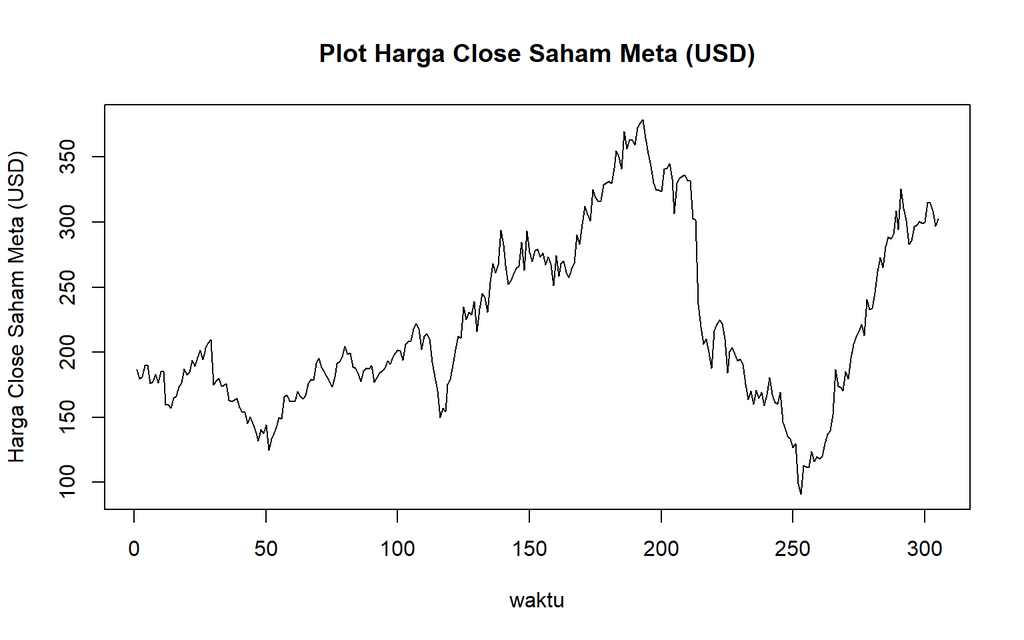

```r
plot.ts(meta.ts, xlab="waktu", ylab="Harga Close Saham Meta (USD)", main="Plot Harga Close Saham Meta (USD)")
```

Berdasarkan plot data deret waktu, terlihat bahwa data memiliki pola tren naik pada periode 1 hingga 190 an. Namun, memasuki periode 200 tren data mulai menurun Berdasarkan pola data, pembagian data latih dan data uji ditetapkan dengan proporsi 90%:10%.

### Plot Data Latih

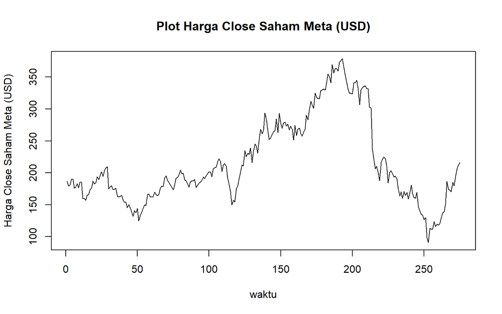

```r
meta.train<-meta$Close[1:275]
train.ts<-ts(meta.train)
plot.ts(train.ts, lty=1, xlab="waktu", ylab="Harga Close Saham Meta (USD)", main="Plot Harga Close Saham Meta (USD)")
```

Berdasarkan plot data deret waktu pada data latih, terlihat bahwa data cenderung memiliki trend yang naik dan turun. Hal ini mengindikasikan bahwa data tidak stasioner dalam rataan.

### Plot Data Uji

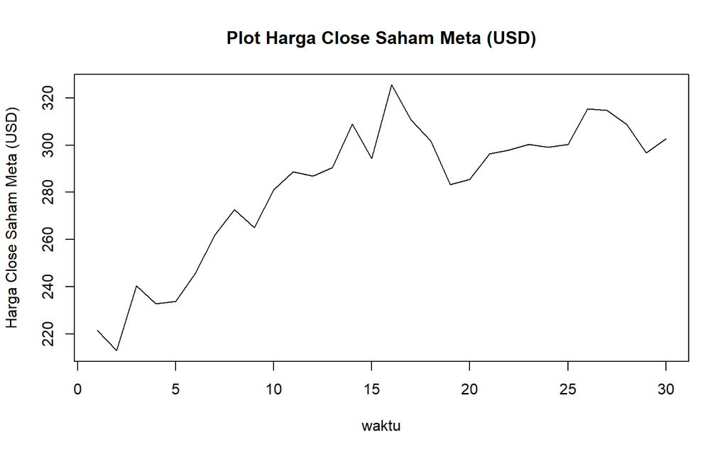

```r
meta.test<-meta$Close[276:305]
test.ts<-ts(meta.test)
plot.ts(test.ts, lty=1, xlab="waktu", ylab="Harga Close Saham Meta (USD)", main="Plot Harga Close Saham Meta (USD)")
```

# Analisis Intervensi pada Model ARIMA

## Membagi Data

```r
#==========MEMBAGI DATA INTERVENSI DAN SEBELUM INTERVENSI
data_sblm_intervensi<-ts(meta.train[1:207])
data_stlh_intervensi<-ts(meta.train[208:275])
```

## Kestasioneran Dalam Ragam

### Plot Box-Cox

```r
index.intervensi <- seq(1:207)
bc.intervensi = boxcox(data_sblm_intervensi~index.intervensi, lambda = seq(-0.5,0.5,by=0.01))
```

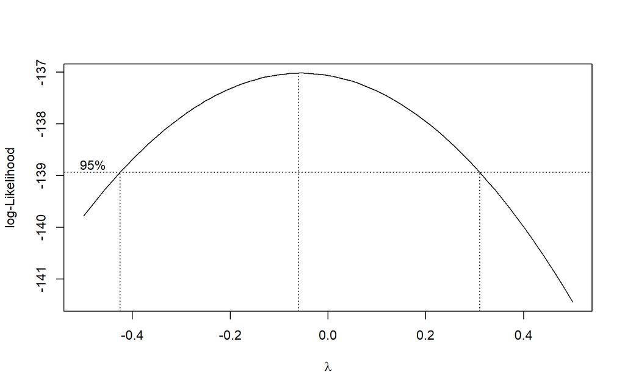

```r
#Nilai Rounded Lambda
lambda.intervensi <- bc.intervensi$x[which.max(bc.intervensi$y)]
lambda.intervensi
```

```
## [1] -0.06
```

```r
#SK
bc.intervensi$x[bc.intervensi$y > max(bc.intervensi$y) - 1/2 * qchisq(.95,1)]
```

```
##  [1] -0.42 -0.41 -0.40 -0.39 -0.38 -0.37 -0.36 -0.35 -0.34 -0.33 -0.32 -0.31
## [13] -0.30 -0.29 -0.28 -0.27 -0.26 -0.25 -0.24 -0.23 -0.22 -0.21 -0.20 -0.19
## [25] -0.18 -0.17 -0.16 -0.15 -0.14 -0.13 -0.12 -0.11 -0.10 -0.09 -0.08 -0.07
## [37] -0.06 -0.05 -0.04 -0.03 -0.02 -0.01  0.00  0.01  0.02  0.03  0.04  0.05
## [49]  0.06  0.07  0.08  0.09  0.10  0.11  0.12  0.13  0.14  0.15  0.16  0.17
## [61]  0.18  0.19  0.20  0.21  0.22  0.23  0.24  0.25  0.26  0.27  0.28  0.29
## [73]  0.30  0.31
```

Plot Boxcox menunjukkan nilai *rounded value* ($\lambda$) optimum sebesar **-0.06** dan pada selang kepercayaan 95% nilai memiliki batas bawah **-0.42** dan batas atas **0.31**. Selang tersebut tidak memuat nilai satu sehingga dapat dikatakan bahwa data yang digunakan tidak stasioner dalam ragam. Nilai lambda = 0 dipilih untuk melakukan transformasi,dengan transformasi yang digunakan adalah logaritma natural.

### Penanganan Ketidakstasioneran dalam ragam (Lambda = 0)

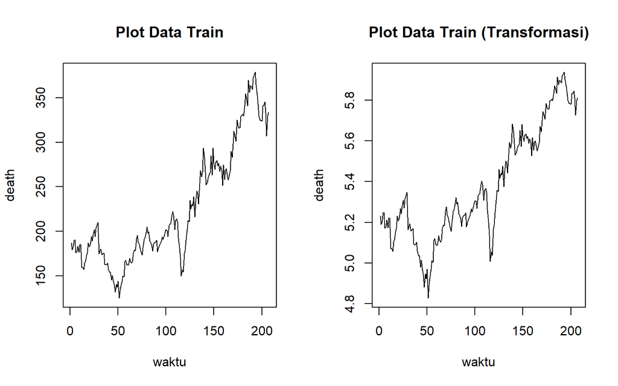

```r
# transformasi dengan nilai lambda = 0
data_boxcox_intervensi = log(data_sblm_intervensi)

par(mfrow=c(1,2))
plot.ts(data_sblm_intervensi, lty=1, xlab="waktu", ylab="death", main="Plot Data Train")
plot.ts(data_boxcox_intervensi, lty=1, xlab="waktu", ylab="death", main="Plot Data Train (Transformasi)")
```

### Plot Box-Cox

```r
index2.intervensi <- seq(1:207)
bc2.intervensi = boxcox(data_boxcox_intervensi~index2.intervensi, lambda = seq(-1.5,3.5,by=0.01))
```

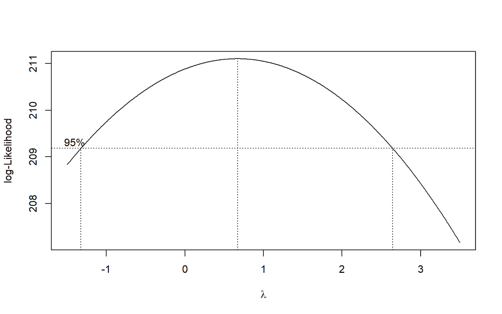

```r
#Nilai Rounded Lambda
lambda2.intervensi <- bc2.intervensi$x[which.max(bc2.intervensi$y)]
lambda2.intervensi
```

```
## [1] 0.67
```

```r
#SK
bc2.intervensi$x[bc2.intervensi$y > max(bc2.intervensi$y) - 1/2 * qchisq(.95,1)]
```

```
##   [1] -1.32 -1.31 -1.30 -1.29 -1.28 -1.27 -1.26 -1.25 -1.24 -1.23 -1.22 -1.21
##  [13] -1.20 -1.19 -1.18 -1.17 -1.16 -1.15 -1.14 -1.13 -1.12 -1.11 -1.10 -1.09
##  [25] -1.08 -1.07 -1.06 -1.05 -1.04 -1.03 -1.02 -1.01 -1.00 -0.99 -0.98 -0.97
##  [37] -0.96 -0.95 -0.94 -0.93 -0.92 -0.91 -0.90 -0.89 -0.88 -0.87 -0.86 -0.85
##  [49] -0.84 -0.83 -0.82 -0.81 -0.80 -0.79 -0.78 -0.77 -0.76 -0.75 -0.74 -0.73
##  [61] -0.72 -0.71 -0.70 -0.69 -0.68 -0.67 -0.66 -0.65 -0.64 -0.63 -0.62 -0.61
##  [73] -0.60 -0.59 -0.58 -0.57 -0.56 -0.55 -0.54 -0.53 -0.52 -0.51 -0.50 -0.49
##  [85] -0.48 -0.47 -0.46 -0.45 -0.44 -0.43 -0.42 -0.41 -0.40 -0.39 -0.38 -0.37
##  [97] -0.36 -0.35 -0.34 -0.33 -0.32 -0.31 -0.30 -0.29 -0.28 -0.27 -0.26 -0.25
## [109] -0.24 -0.23 -0.22 -0.21 -0.20 -0.19 -0.18 -0.17 -0.16 -0.15 -0.14 -0.13
## [121] -0.12 -0.11 -0.10 -0.09 -0.08 -0.07 -0.06 -0.05 -0.04 -0.03 -0.02 -0.01
## [133]  0.00  0.01  0.02  0.03  0.04  0.05  0.06  0.07  0.08  0.09  0.10  0.11
## [145]  0.12  0.13  0.14  0.15  0.16  0.17  0.18  0.19  0.20  0.21  0.22  0.23
## [157]  0.24  0.25  0.26  0.27  0.28  0.29  0.30  0.31  0.32  0.33  0.34  0.35
## [169]  0.36  0.37  0.38  0.39  0.40  0.41  0.42  0.43  0.44  0.45  0.46  0.47
```

[output cut: 19 more lines]

Plot Boxcox memuat nilai satu sehingga dapat dikatakan bahwa data yang digunakan sudah stasioner dalam ragam.

## Kestasioneran Dalam Rataan

### Plot ACF

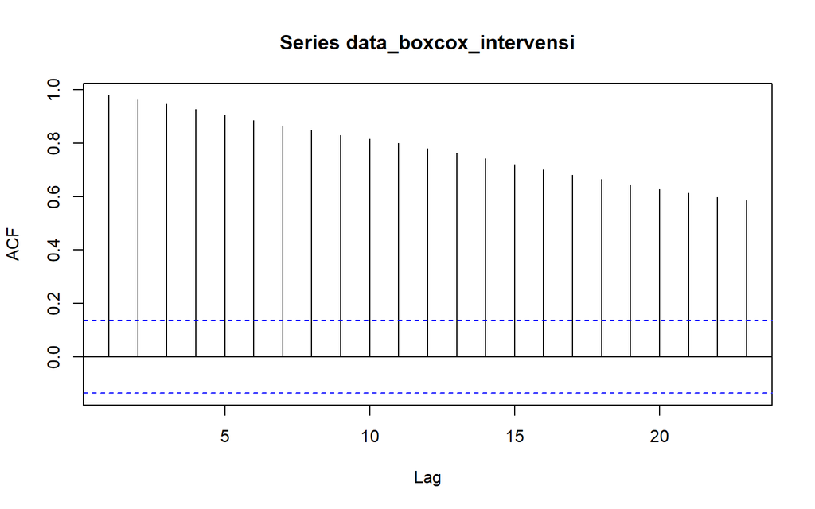

```r
acf(data_boxcox_intervensi)
```

Berdasarkan plot ACF, terlihat bahwa plot ACF data menurun secara perlahan (*tails of slowly*). Hal ini juga menjadi indikasi bahwa data tidak stasioner dalam rataan

### Uji ADF

```r
tseries::adf.test(data_boxcox_intervensi)
```

```
##
##  Augmented Dickey-Fuller Test
##
## data:  data_boxcox_intervensi
## Dickey-Fuller = -2.8288, Lag order = 5, p-value = 0.2287
## alternative hypothesis: stationary
```

$H_0$ : Data tidak stasioner dalam rataan

$H_1$ : Data stasioner dalam rataan

Berdasarkan uji ADF tersebut, didapat *p-value* sebesar 0.2287 yang lebih besar dari taraf nyata 5% sehingga tak tolak $H_0$ dan menandakan bahwa data tidak stasioner dalam rataan. Hal ini sesuai dengan hasil eksplorasi menggunakan plot time series dan plot ACF, sehingga ketidakstasioneran model kedepannya harus ditangani

### Penanganan Ketidakstasioneran dalam rataan

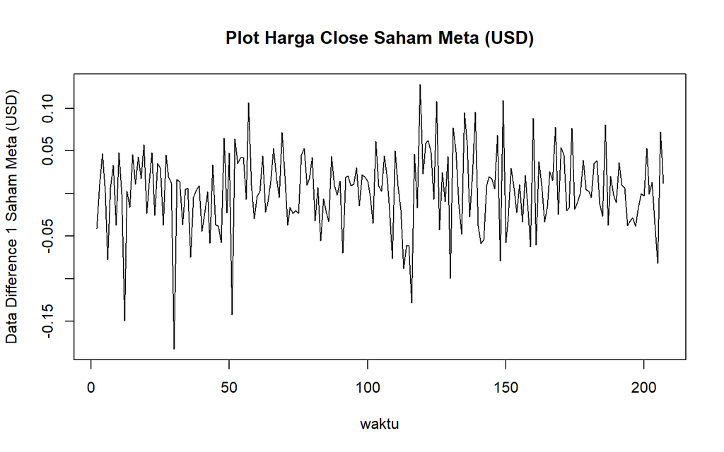

```r
train.diff.intervensi<-diff(data_boxcox_intervensi,differences = 1)
plot.ts(train.diff.intervensi, lty=1, xlab="waktu", ylab="Data Difference 1 Saham Meta (USD)", main="Plot Harga Close Saham Meta (USD)")
```

Berdasarkan plot data deret waktu, terlihat bahwa data sudah stasioner dalam rataan ditandai dengan data bergerak pada nilai tengah tertentu (tidak terdapat trend ataupun musiman pada data)

#### Plot ACF

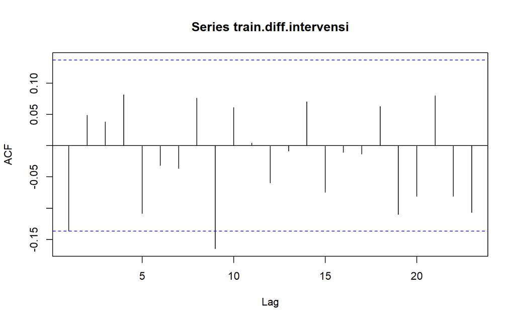

```r
acf(train.diff.intervensi)
```

Berdasarkan plot tersebut, tidak terlihat adanya *tailss off slowly*. Namun, akan dipastikan kembali dengan pengujian formal.

#### Uji ADF

```r
tseries::adf.test(train.diff.intervensi)
```

```
##
##  Augmented Dickey-Fuller Test
##
## data:  train.diff.intervensi
## Dickey-Fuller = -6.1559, Lag order = 5, p-value = 0.01
## alternative hypothesis: stationary
```

$H_0$ : Data tidak stasioner dalam rataan

$H_1$ : Data stasioner dalam rataan

Berdasarkan uji ADF tersebut, didapat *p-value* sebesar 0.01 yang lebih kecil dari taraf nyata 5% sehingga tolak $H_0$ atau data stasioner dalam rataan. Dalam hal ini ketidakstasioneran data dalam rataan sudah berhasil ditangani dan dapat dilanjutkan ke pemodelan

## Identifikasi Model

### Plot ACF

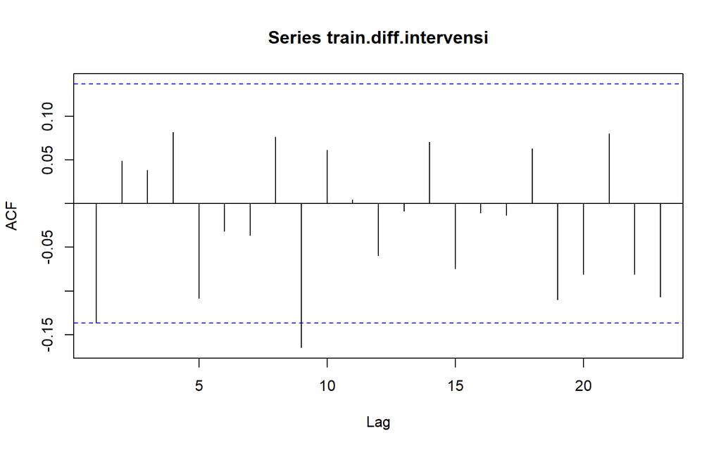

```r
acf(train.diff.intervensi)
```

Berdasarkan plot tersebut, terlihat bahwa plot ACF tidak *cut off*.

### Plot PACF

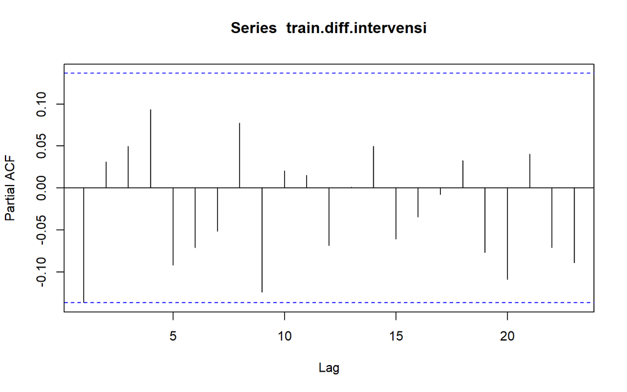

```r
pacf(train.diff.intervensi)
```

Berdasarkan plot tersebut, terlihat bahwa plot PACF tidak *cuts off*. Plot ACF dan PACF tidak menghasilkan model tentatif, sehingga akan digunakan plot EACF.

### Plot EACF

```r
eacf(train.diff.intervensi)
```

```
## AR/MA
##   0 1 2 3 4 5 6 7 8 9 10 11 12 13
## 0 o o o o o o o o x o o  o  o  o
## 1 x o o o o o o o o o o  o  o  o
## 2 x o o o o o o o o o o  o  o  o
## 3 x o x o o o o o o o o  o  o  o
## 4 x x x x o o o o o o o  o  o  o
## 5 x o x x o o o o o o o  o  o  o
## 6 x o x x x x o o o o o  o  o  o
## 7 x o x x x x o o x o o  o  o  o
```

Identifikasi model menggunakan plot EACF dilakukan dengan melihat ujung segitiga pada pola segitiga nol. Dalam hal ini model tentatif yang terbentuk adalah ARIMA(1,1,1), ARIMA(2,1,1), ARIMA(3,1,3).

Untuk eksplorasi, akan ditambahkan juga model ARIMA(0,1,1)